# Predictors of Wine Quality

August 9, 2019

## Overview

The Predictors of Wine Quality app allows for the exploration and modeling of various physicochemical properties (acidity, density, sulfates, etc.) that may predict wine quality.

Data used by this app was obtained from [this link](http://www3.dsi.uminho.pt/pcortez/wine/) (Cortez et al., 2009). The dataset includes physicochemical property values for various red and white wines from the Portuguese [vinho verde](http://www.vinhoverde.pt/en/) variety.

The app has three main functionalities, each located in a separate tab:

- **exploration of variables** in this dataset reflecting different physicochemical properties of vinho verde wine
- constructing and evaluating multiple linear **regression** models to examine the relationship between properties and quality
- **prediction** of wine quality based on inputted values of various physicochemical properties

## Explore Variables Tab

For example, to explore **density** values for white vinho verde wines, you could use the first tab. After selecting relevant preferences, the app will display 4 visualizations. including the plots below, that allow for exploration of the variable:

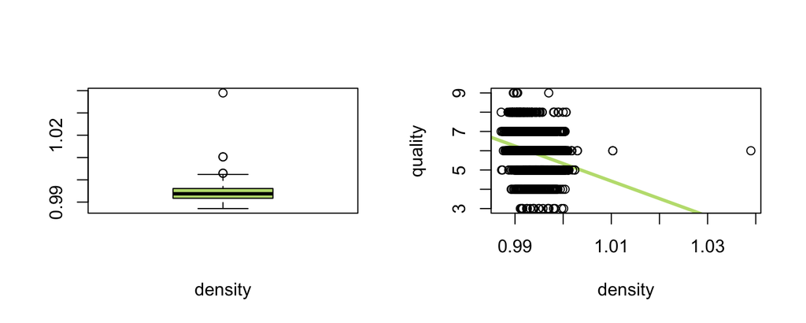

```r
par(mfrow = c(1,2))
p1 <- boxplot(data$density, col = "#BEDE7E", xlab = "density")
p2 <- plot(data$density, data$quality, xlab = "density", ylab = "quality",
           abline(lm(quality ~ density, data = data),
                  lwd = 3, col = "#BEDE7E"))
```

## Regression Tab

After exploring variables, you might want to model the quality of white vinho verde based on only *acidity*, *density*, and *sulfates*. After inputting these options on the app’s second tab, the app would display a summary of the model fit along with diagnostic plots such as those below:

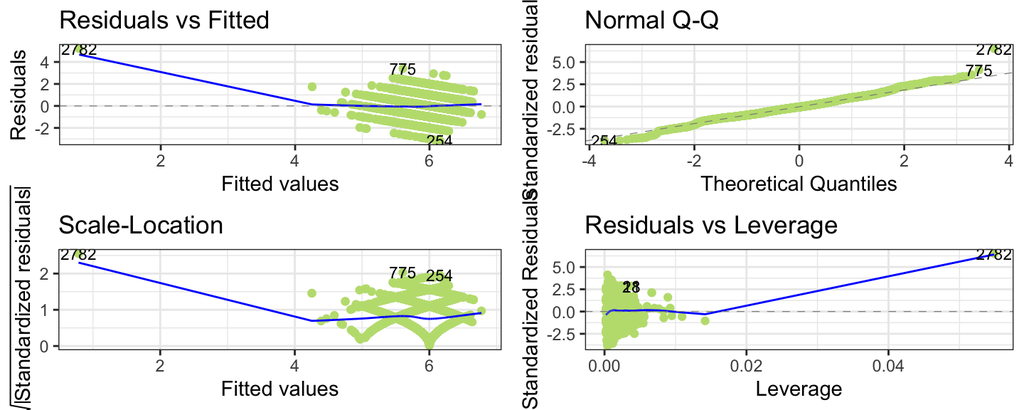

This model fit has an R-squared value of 0.1339599. You could try to improve it by adding more predictors and removing outliers, all of which are options in the app.

## Prediction Tab

Finally, you might be interested in predicting the quality of a white vinho verde, based on custom values of all the available physicochemical properties. On the third tab, you could use the sliders to select custom values of each variable.

The app would then predict a quality value according to the model below, and display the predicted quality value:

```r
my_model <- lm(quality ~ ., data = data)
predicted_value <- round(as.vector(predict(my_model,
    newdata = data.frame(acidity = 0.7, alcohol = 12,
                        chlorides = 0.2, density = 0.998,
                        sugar = 4.7, sulfates = 1.32))), digits = 1)
```

5.4 /10

In addition, the prediction tab includes a separate plot for each variable, showing the raw data along with points indicating the predicted quality for each’s inputted value, if all other inputs are held at their mean value.